# Capstone Project

Carme Mias

18/04/2020

# Project description

Find 3 replacement players where: 1. The total combined salary of the three players can not exceed 15 million dollars. 2. Their combined number of At Bats (AB) needs to be equal to or greater than the lost players. 3. Their mean OBP had to equal to or greater than the mean OBP of the lost players.

# Steps

## Import Data

```r
batting <- read.csv('~/Documents/learning/1.R/udemy/practice/Capstone_Project/data/Batting.csv')
salaries <- read.csv('~/Documents/learning/1.R/udemy/practice/Capstone_Project/data/Salaries.csv')
```

### Preview Imported Data

```r
str(batting)
```

```
## 'data.frame':    97889 obs. of  24 variables:
##  $ playerID : Factor w/ 18107 levels "aardsda01","aaronha01",..: 1 1 1 1 1 1 1 2 2 2 ...
##  $ yearID   : int  2004 2006 2007 2008 2009 2010 2012 1954 1955 1956 ...
##  $ stint    : int  1 1 1 1 1 1 1 1 1 1 ...
##  $ teamID   : Factor w/ 149 levels "ALT","ANA","ARI",..: 117 35 33 16 116 116 93 80 80 80 ...
##  $ lgID     : Factor w/ 6 levels "AA","AL","FL",..: 4 4 2 2 2 2 2 4 4 4 ...
##  $ G        : int  11 45 25 47 73 53 1 122 153 153 ...
##  $ G_batting: int  11 43 2 5 3 4 NA 122 153 153 ...
##  $ AB       : int  0 2 0 1 0 0 NA 468 602 609 ...
##  $ R        : int  0 0 0 0 0 0 NA 58 105 106 ...
##  $ H        : int  0 0 0 0 0 0 NA 131 189 200 ...
##  $ X2B      : int  0 0 0 0 0 0 NA 27 37 34 ...
##  $ X3B      : int  0 0 0 0 0 0 NA 6 9 14 ...
##  $ HR       : int  0 0 0 0 0 0 NA 13 27 26 ...
##  $ RBI      : int  0 0 0 0 0 0 NA 69 106 92 ...
##  $ SB       : int  0 0 0 0 0 0 NA 2 3 2 ...
##  $ CS       : int  0 0 0 0 0 0 NA 2 1 4 ...
##  $ BB       : int  0 0 0 0 0 0 NA 28 49 37 ...
##  $ SO       : int  0 0 0 1 0 0 NA 39 61 54 ...
##  $ IBB      : int  0 0 0 0 0 0 NA NA 5 6 ...
##  $ HBP      : int  0 0 0 0 0 0 NA 3 3 2 ...
##  $ SH       : int  0 1 0 0 0 0 NA 6 7 5 ...
##  $ SF       : int  0 0 0 0 0 0 NA 4 4 7 ...
##  $ GIDP     : int  0 0 0 0 0 0 NA 13 20 21 ...
##  $ G_old    : int  11 45 2 5 NA NA NA 122 153 153 ...
```

```r
knitr::kable(head(batting), caption="Preview of the Batting dataset")
```

Preview of the Batting dataset

| playerID | yearID | stint | teamID | lgID | G | G_batting | AB | R | H | X2B | X3B | HR | RBI | SB | CS | BB | SO | IBB | HBP | SH | SF | GIDP | G_old |
| --- | --- | --- | --- | --- | --- | --- | --- | --- | --- | --- | --- | --- | --- | --- | --- | --- | --- | --- | --- | --- | --- | --- | --- |
| aardsda01 | 2004 | 1 | SFN | NL | 11 | 11 | 0 | 0 | 0 | 0 | 0 | 0 | 0 | 0 | 0 | 0 | 0 | 0 | 0 | 0 | 0 | 0 | 11 |
| aardsda01 | 2006 | 1 | CHN | NL | 45 | 43 | 2 | 0 | 0 | 0 | 0 | 0 | 0 | 0 | 0 | 0 | 0 | 0 | 0 | 1 | 0 | 0 | 45 |
| aardsda01 | 2007 | 1 | CHA | AL | 25 | 2 | 0 | 0 | 0 | 0 | 0 | 0 | 0 | 0 | 0 | 0 | 0 | 0 | 0 | 0 | 0 | 0 | 2 |
| aardsda01 | 2008 | 1 | BOS | AL | 47 | 5 | 1 | 0 | 0 | 0 | 0 | 0 | 0 | 0 | 0 | 0 | 1 | 0 | 0 | 0 | 0 | 0 | 5 |
| aardsda01 | 2009 | 1 | SEA | AL | 73 | 3 | 0 | 0 | 0 | 0 | 0 | 0 | 0 | 0 | 0 | 0 | 0 | 0 | 0 | 0 | 0 | 0 | NA |
| aardsda01 | 2010 | 1 | SEA | AL | 53 | 4 | 0 | 0 | 0 | 0 | 0 | 0 | 0 | 0 | 0 | 0 | 0 | 0 | 0 | 0 | 0 | 0 | NA |

```r
str(salaries)
```

```
## 'data.frame':    23956 obs. of  5 variables:
##  $ yearID  : int  1985 1985 1985 1985 1985 1985 1985 1985 1985 1985 ...
##  $ teamID  : Factor w/ 35 levels "ANA","ARI","ATL",..: 4 4 4 4 4 4 4 4 4 4 ...
##  $ lgID    : Factor w/ 2 levels "AL","NL": 1 1 1 1 1 1 1 1 1 1 ...
##  $ playerID: Factor w/ 4668 levels "aardsda01","aasedo01",..: 2961 2517 3566 2304 1332 394 4061 2604 3634 2722 ...
##  $ salary  : int  1472819 1090000 800000 725000 641667 625000 581250 560000 558333 547143 ...
```

```r
knitr::kable(head(salaries), caption="Preview of the Salaries dataset")
```

Preview of the Salaries dataset

| yearID | teamID | lgID | playerID | salary |
| --- | --- | --- | --- | --- |
| 1985 | BAL | AL | murraed02 | 1472819 |
| 1985 | BAL | AL | lynnfr01 | 1090000 |
| 1985 | BAL | AL | ripkeca01 | 800000 |
| 1985 | BAL | AL | lacyle01 | 725000 |
| 1985 | BAL | AL | flanami01 | 641667 |
| 1985 | BAL | AL | boddimi01 | 625000 |

## Initial Data Exploration

The Oackland Athletics team ID is: OAK The lost players were: Jason Giambi (giambja01), Johnny Damon (damonjo01) and Jason Isringhausen (isrinja01)

### Salaries Dataset

We’ll assume that the players available to buy are those who were in other teams in 2001. The IDs of all available players will be stored in vector *available_players*.

```r
nonOAK_filter <- salaries$teamID != 'OAK' & salaries$yearID == 2001
filtered_salaries <- salaries[nonOAK_filter,]

available_players <- as.vector(filtered_salaries$playerID)

print( paste0("There are ", length(available_players), " players in the list.") )
```

```
## [1] "There are 833 players in the list."
```

From the filtered salaries dataset, we only need the player IDs and their salaries:

```r
ap_2001_sal <- filtered_salaries[,c('playerID', 'salary')]

knitr::kable(head(ap_2001_sal), caption="Preview of the available players' salaries data")
```

Preview of the available players’ salaries data

|  | playerID | salary |
| --- | --- | --- |
| 13100 | vaughmo01 | 13166667 |
| 13101 | salmoti01 | 6500000 |
| 13102 | anderga01 | 4500000 |
| 13103 | erstada01 | 3450000 |
| 13104 | percitr01 | 3400000 |
| 13105 | valdeis01 | 2500000 |

### Batting Dataset

The lost players’ combined AB is found and assigned to object *lp_combined_AB*:

```r
lost_players <- c('giambja01','damonjo01', 'isrinja01')
lp_filter <- (batting$playerID %in% lost_players) & batting$yearID == 2001
lp_2001_batting <- batting[lp_filter,]
lp_combined_AB <- lp_2001_batting$AB %>% as.vector() %>% sum()

print(paste0("The lost players' combined Average Batting is ", lp_combined_AB))
```

```
## [1] "The lost players' combined Average Batting is 1164"
```

Now, let’s use the batting dataset to filter the 2001 data for the available players with at least 1 hit. The new filtered batting dataset is assigned to object *ap_batting*.

```r
batting_filter <- batting$playerID %in% available_players &
                  batting$yearID == 2001 & batting$H > 0 & !is.na(batting$H)
ap_batting <- batting[batting_filter,]

print(paste0("There are ", nrow(ap_batting), " available players left."))
```

```
## [1] "There are 607 available players left."
```

## Other Useful Calculations

### Batting Average

First, we’ll define a reusable function to work out the proportions and then use it to add a new variable Batting Average, BA, to the Batting dataset:

```r
set_proportion <- function(x, y){
  result <- 0
  if( y > 0) {
    result <-x/y
  }
  return(result)
}

for(row in 1:nrow(ap_batting)){
  ap_batting[row, 'BA'] <- set_proportion(ap_batting$H[row], ap_batting$AB[row])
}

knitr::kable(head(ap_batting[,c('playerID', 'yearID', 'AB', 'H', 'BA')]), caption = "Preview of the available players' new Battting Average(BA) variable")
```

Preview of the available players’ new Battting Average(BA) variable

|  | playerID | yearID | AB | H | BA |
| --- | --- | --- | --- | --- | --- |
| 100 | abbotje01 | 2001 | 42 | 11 | 0.2619048 |
| 121 | abbotku01 | 2001 | 9 | 2 | 0.2222222 |
| 134 | abbotpa01 | 2001 | 4 | 1 | 0.2500000 |
| 209 | abreubo01 | 2001 | 588 | 170 | 0.2891156 |
| 462 | adamste01 | 2001 | 39 | 2 | 0.0512821 |
| 558 | agbaybe01 | 2001 | 296 | 82 | 0.2770270 |

Let’s double check that we don’t have empty Batting averages:

```r
print(paste0("Are there any empty batting averages in the data frame? ", any(is.na(batting$BA)) ))
```

```
## [1] "Are there any empty batting averages in the data frame? FALSE"
```

### On Base Percentage

The On-base percentage is calculated using this formula: *OBP=(H+BB+HBP)/(AB+BB+HBP+SF)* Further info can be found from [Wikipedia](http://en.wikipedia.org/wiki/On-base_percentage).

For readability’s sake, we’ll also create a separate function that will be used to calculate the OBP for each observation amd add it to the filtered Batting data frame.

```r
set_obp <- function(df){
  result <- 0
  numerator <- df$H + df$BB + df$HBP
  denominator <- df$AB + df$BB + df$HBP + df$SF

  if(denominator>0){
    result <- numerator/denominator
  }

  return(result)
}

ap_batting$OBP <- set_obp(ap_batting)

knitr::kable(head(ap_batting[, c('playerID', 'AB', 'H', 'BB', 'HBP', 'SF', 'OBP') ]), caption="Preview of the available players' new On-Base Percentage variable")
```

Preview of the available players’ new On-Base Percentage variable

|  | playerID | AB | H | BB | HBP | SF | OBP |
| --- | --- | --- | --- | --- | --- | --- | --- |
| 100 | abbotje01 | 42 | 11 | 3 | 1 | 0 | 0.3260870 |
| 121 | abbotku01 | 9 | 2 | 0 | 0 | 0 | 0.2222222 |
| 134 | abbotpa01 | 4 | 1 | 0 | 0 | 0 | 0.2500000 |
| 209 | abreubo01 | 588 | 170 | 106 | 1 | 9 | 0.3934659 |
| 462 | adamste01 | 39 | 2 | 3 | 0 | 1 | 0.1162791 |
| 558 | agbaybe01 | 296 | 82 | 36 | 5 | 1 | 0.3639053 |

As one of the project conditions is that the selected players must have a combined mean OBP equal to or greater than the mean OBP of the lost players, we need to calculate the lost players’ mean OBP. We assign this to object *lp_mean_OBP*:

```r
for(row in 1:nrow(lp_2001_batting)){
  lp_2001_batting[row, 'OBP'] <- set_obp(lp_2001_batting[row,])
}
lp_mean_OBP <- mean(lp_2001_batting$OBP)

print(paste0("Lost players' mean OBP is ", lp_mean_OBP))
```

```
## [1] "Lost players' mean OBP is 0.266809853598667"
```

### Slugging Percentage

**(From the notes) Hint: For SLG, you need 1B (Singles), this isn’t in your data frame.** **However you can calculate it by subtracting doubles,triples, and home runs from total hits (H):** *1B = H-2B-3B-HR*

```r
set_x1b <- function(h, x2b=0, x3b=0, hr=0){
  return(h-x2b-x3b-hr)
}
ap_batting$X1B <- set_x1b(ap_batting$H, ap_batting$X2B, ap_batting$X3B, ap_batting$HR)

for(row in 1:nrow(ap_batting)){
  ap_batting[row, 'SLG'] <- set_proportion(ap_batting$H[row], ap_batting$X1B[row])
}

knitr::kable(head(ap_batting[, c('playerID','H', 'X1B', 'SLG') ]), caption="Preview of the available players' new Sluggish Percentage variable")
```

Preview of the available players’ new Sluggish Percentage variable

|  | playerID | H | X1B | SLG |
| --- | --- | --- | --- | --- |
| 100 | abbotje01 | 11 | 8 | 1.375000 |
| 121 | abbotku01 | 2 | 2 | 1.000000 |
| 134 | abbotpa01 | 1 | 1 | 1.000000 |
| 209 | abreubo01 | 170 | 87 | 1.954023 |
| 462 | adamste01 | 2 | 1 | 2.000000 |
| 558 | agbaybe01 | 82 | 60 | 1.366667 |

## Merge Salary and Batting Data

Now that we have everything we need, let’s bring it all together:

```r
combined_data <- merge(ap_batting, ap_2001_sal, by="playerID")

knitr::kable(head(combined_data[, c('playerID', 'salary', 'AB', 'BA', 'OBP', 'SLG')] ), caption="Preview of the combined data")
```

Preview of the combined data

| playerID | salary | AB | BA | OBP | SLG |
| --- | --- | --- | --- | --- | --- |
| abbotje01 | 300000 | 42 | 0.2619048 | 0.3260870 | 1.375000 |
| abbotku01 | 600000 | 9 | 0.2222222 | 0.2222222 | 1.000000 |
| abbotpa01 | 1700000 | 4 | 0.2500000 | 0.2500000 | 1.000000 |
| abreubo01 | 4983000 | 588 | 0.2891156 | 0.3934659 | 1.954023 |
| adamste01 | 2600000 | 39 | 0.0512821 | 0.1162791 | 2.000000 |
| agbaybe01 | 260000 | 296 | 0.2770270 | 0.3639053 | 1.366667 |

## Find replacement players

To make sure the final salary combination is not over the limit, we’ll start by considering only those players with a salary less or equal to the maximum divided by 3:

```r
combined_data <- combined_data[ combined_data$salary <= 5000000, ]

print(paste0("There are ", nrow(combined_data), " available players left."))
```

```
## [1] "There are 492 available players left."
```

Let’s see how this data looks like:

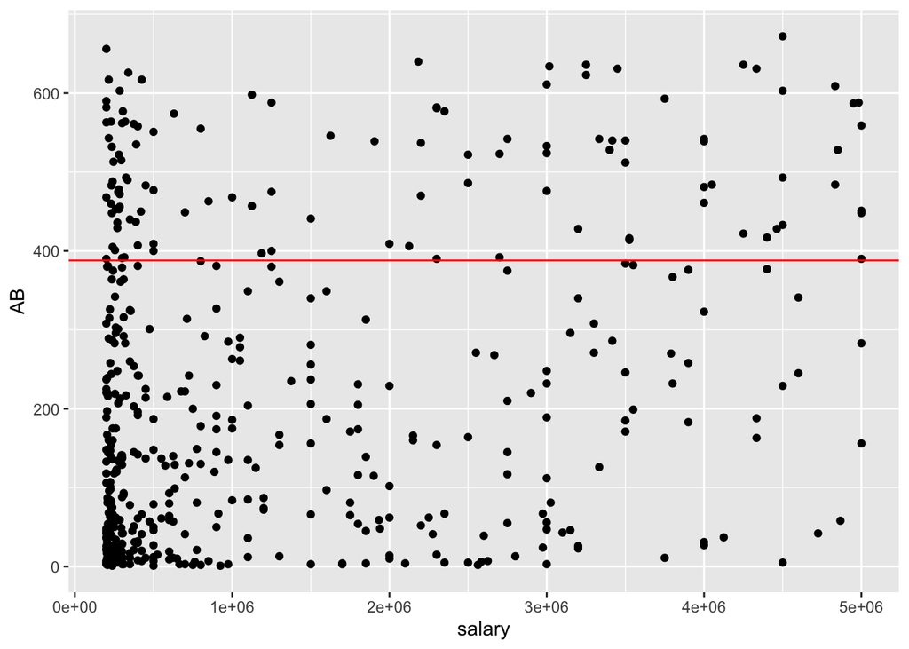

```r
ggplot(combined_data, aes(x=salary, y=AB)) +
  geom_point() +
  geom_hline( yintercept = lp_combined_AB/3, color = "red" )
```

Let’s make sure we only take only those players with an AB higher than the lost players mean and plot their OBP to salary data:

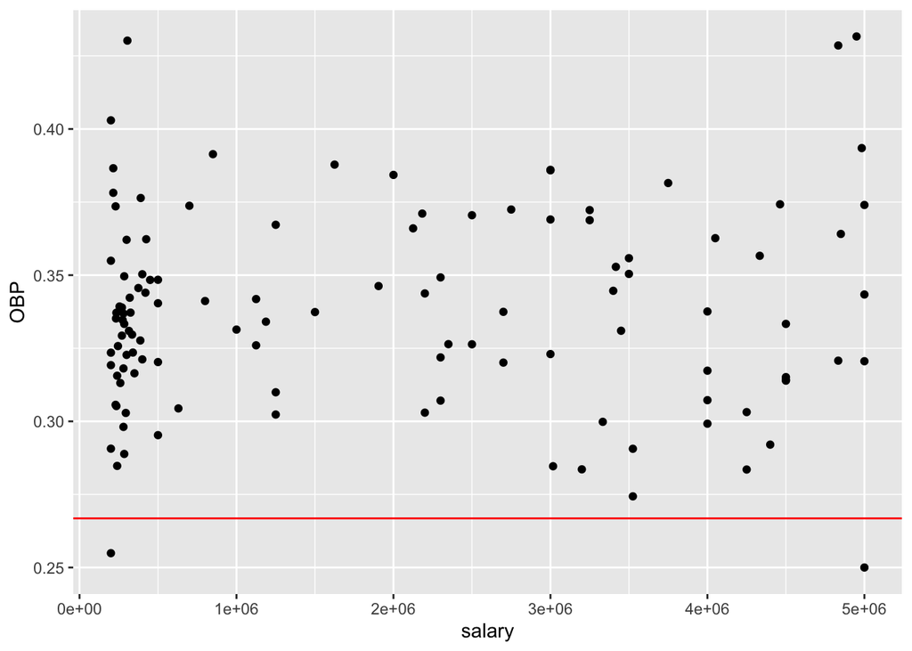

```r
combined_data <- combined_data[ combined_data$AB > lp_combined_AB/3 ,]

ggplot(combined_data, aes(x=salary, y=OBP)) + geom_point() + geom_hline( yintercept = lp_mean_OBP, color = "red" )
```

We can see from this last graph that most of the remaining available players have a mean OBP above the lost players’.

```r
combined_data <- combined_data[combined_data$OBP > lp_mean_OBP,]

print(paste0("There are ", nrow(combined_data), " players left."))
```

```
## [1] "There are 115 players left."
```

So picking any random 3 should do the job:

```r
random_row_numbers <- runif(3, 1, nrow(combined_data))
player1 <- combined_data[random_row_numbers[1],]
player2 <- combined_data[random_row_numbers[2],]
player3 <- combined_data[random_row_numbers[3],]

print(paste("The selected players are:", player1$playerID, player2$playerID, player3$playerID, sep=" "))
```

```
## [1] "The selected players are: quinnma01 hidalri01 winnra01"
```

```r
print(paste0( "Their combined salary is: ", dollar(sum( c(player1$salary, player2$salary, player3$salary) )) ))
```

```
## [1] "Their combined salary is: $4,050,000"
```

```r
print(paste0( "Their combined AB is: ", sum( c(player1$AB, player2$AB, player3$AB) ), ", whilst the lost players combined AB is: ", lp_combined_AB ))
```

```
## [1] "Their combined AB is: 1394, whilst the lost players combined AB is: 1164"
```

```r
print(paste0( "Their mean OBP is: $", mean( c(player1$OBP, player2$OBP, player3$OBP) ), ", whilst the lost players mean OBP is: ", lp_mean_OBP ))
```

```
## [1] "Their mean OBP is: $0.33095416507249, whilst the lost players mean OBP is: 0.266809853598667"
```